# Mammal data - National (Desert Units)

Talia Gabay

2025-11-17

```r
P <- P_byplot[Unit %in% c("Arid Desert", "Inland Sands", "Mediterranean Desert Transition Zone", "Negev Highlands")]
```

Monitoring started in 2014 (5 monitoring cycles)

4 desert units, each have 2 types of transects - near or far from settlements/agriculture

Each site was sampled for 5 monitoring cycles besides inland sand sites, which were sampled for only 3 cycles

Let’s first validate the data:

```r
#include rare species in analysis
P.anal <- copy(P) # set a fixed variable name for analysis, if want to switch between data WITH rare #species and data WITHOUT rare species then only change once here

#Validate factors and levels

P.anal$Settlements <- as.factor(P.anal$Settlements)
print("Settlements has 2 levels")
```

```
## [1] "Settlements has 2 levels"
```

```r
print(levels(P.anal$Settlements))
```

```
## [1] "Far"  "Near"
```

```r
P.anal$Agriculture <- as.factor(P.anal$Agriculture)
print("Agriculture has 2 levels")
```

```
## [1] "Agriculture has 2 levels"
```

```r
print(levels(P.anal$Agriculture))
```

```
## [1] "Far"  "Near"
```

```r
P.anal$Unit <- as.factor(P.anal$Unit)
print("Unit has 4 levels")
```

```
## [1] "Unit has 4 levels"
```

```r
print(levels(P.anal$Unit))
```

```
## [1] "Arid Desert"
## [2] "Inland Sands"
## [3] "Mediterranean Desert Transition Zone"
## [4] "Negev Highlands"
```

```r
P.anal$Site <- as.factor(P.anal$Site)
print("Site has 18 levels")
```

```
## [1] "Site has 18 levels"
```

```r
print(levels(P.anal$Site))
```

```
##  [1] "Beer Milka" "Beit Yatir" "Bislach"    "Ein Yahav"  "Ezuz"
##  [6] "Har Amasa"  "Lahav"      "Lehavim"    "Lotan"      "Merhav Am"
## [11] "Mirsham"    "Paran"      "Sde Boker"  "Secher"     "Shunra"
## [16] "Yeruham"    "Yotvata"    "Zofar"
```

```r
P.anal$Transect <- as.factor(P.anal$Transect)
print("Transect has 38 levels")
```

```
## [1] "Transect has 38 levels"
```

```r
print(levels(P.anal$Transect))
```

```
##  [1] "Beer Milka Far Shifting 1"     "Beer Milka Far Shifting 2"
##  [3] "Beer Milka Far Shifting 3"     "Beer Milka Near Semi-Shifting"
##  [5] "Beer Milka Near Shifting"      "Beit Yatir Far"
##  [7] "Beit Yatir Near"               "Bislach Far"
##  [9] "Bislach Near"                  "Ein Yahav Far"
## [11] "Ein Yahav Near"                "Ezuz Far"
## [13] "Ezuz Near"                     "Har Amasa Far"
## [15] "Har Amasa Near"                "Lahav Far"
## [17] "Lahav Near"                    "Lehavim Far"
## [19] "Lehavim Near"                  "Lotan Far"
## [21] "Lotan Near"                    "Merhav Am Far"
## [23] "Merhav Am Near"                "Mirsham Far"
## [25] "Mirsham Near"                  "Paran Far"
## [27] "Paran Near"                    "Sde Boker Far"
## [29] "Sde Boker Near"                "Secher Far Semi-Shifting"
## [31] "Secher Far Shifting"           "Shunra Far Semi-Shifting"
## [33] "Yeruham Far"                   "Yeruham Near"
## [35] "Yotvata Far"                   "Yotvata Near"
## [37] "Zofar Far"                     "Zofar Near"
```

```r
print("RICHNESS WITH RARE SPECIES")
```

```
## [1] "RICHNESS WITH RARE SPECIES"
```

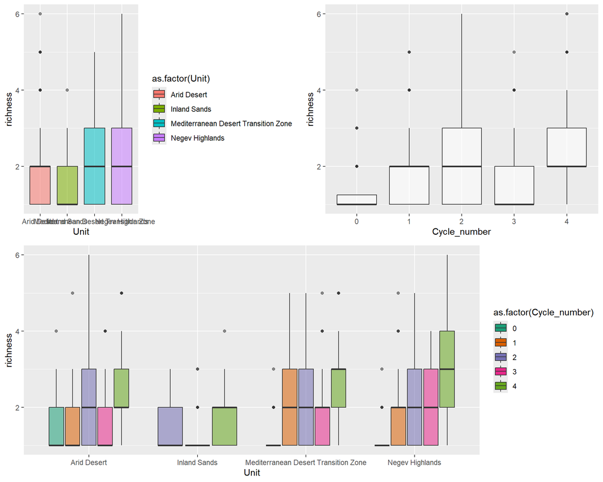

```r
plot_alpha_diversity(P, x_val = "Unit", y_val = "richness", ylab_val = "richness", xlab_val = "Unit", fill_val = "Unit")
```

```r
col_names <- c("Cycle_number",  "Deployment.id_new",    "Unit", "Subunit",  "Site", "Distance_rescaled", "Distance_agri_rescaled", "Year", "rescaled_Time.Diff", "sinus_Monitoring.Time.Diff", "cosinus_Monitoring.Time.Diff", "Transect", "Transect_with_date")

spp <- P.anal[,27:40]
# filter out species with zero counts
print(colSums(spp))
```

```
##      Canis aureus       Canis lupus     Capra nubiana Dama mesopotamica
##              1727               241               405                 0
##    Equus hemionus    Gazella dorcas   Gazella gazella     Hyaena hyaena
##               116              1006               950               250
##    Hystrix indica    Lepus capensis       Meles meles     Oryx leucoryx
##               734              1062                39                72
##        Sus scrofa     Vulpes vulpes
##                 0              1804
```

```
## Overlapping points were shifted along the y-axis to make them visible.
```

```
##
##  PIPING TO 2nd MVFACTOR
```

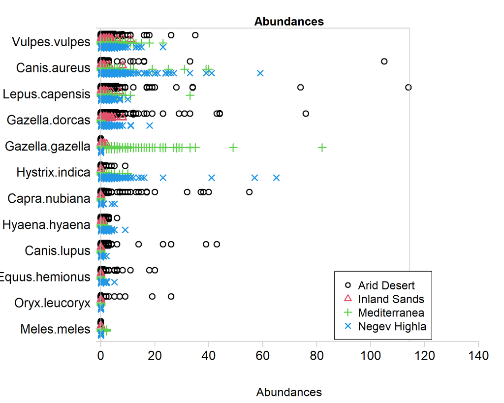

```r
spp <- spp[,.SD,.SDcols = colSums(spp)>0]
spp <- mvabund(spp)

plot(spp ~ P.anal$Unit, overall.main="raw abundances", transformation = "no")
```

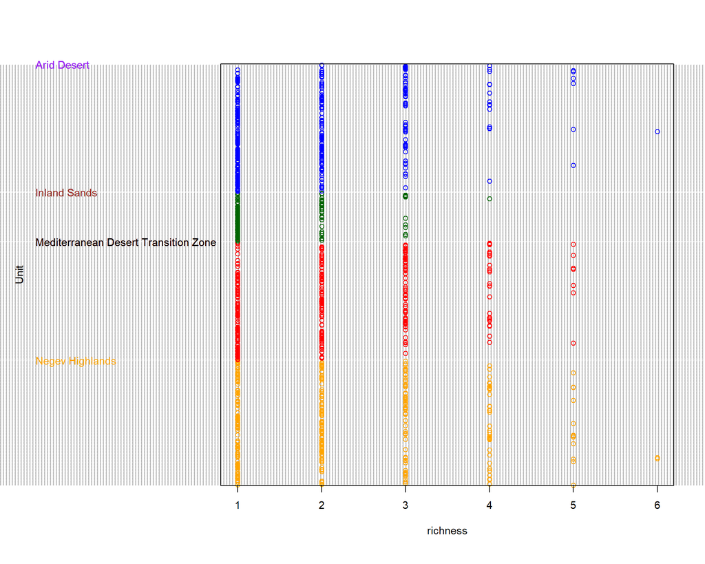

```r
my_cols <- c("blue", "darkgreen", "red", "orange", "purple", "brown", "black")
dotchart(P.anal$richness, ylab = "Unit",
         groups = P.anal$Unit, gcolor = my_cols,
         color = my_cols[P.anal$Unit],
         cex = 0.9,  pch = 1, xlab = "richness")
```

```r
kable(summary(P.anal[,.(richness, abundance, rescaled_Time.Diff, cosinus_Monitoring.Time.Diff, sinus_Monitoring.Time.Diff, Unit, Site, Transect, Distance_rescaled, Distance_agri_rescaled)]))
```

|  | richness | abundance | rescaled_Time.Diff | cosinus_Monitoring.Time.Diff | sinus_Monitoring.Time.Diff | Unit | Site | Transect | Distance_rescaled | Distance_agri_rescaled |
| --- | --- | --- | --- | --- | --- | --- | --- | --- | --- | --- |
|  | Min. :1.000 | Min. : 1.000 | Min. :-1.2473 | Min. :-1.0000 | Min. :-0.99999 | Arid Desert :303 | Beer Milka: 81 | Lotan Far : 38 | Min. :-0.9136 | Min. :-0.681899 |
|  | 1st Qu.:1.000 | 1st Qu.: 2.000 | 1st Qu.:-0.4351 | 1st Qu.:-0.5328 | 1st Qu.:-0.58061 | Inland Sands :116 | Yeruham : 69 | Yeruham Near : 37 | 1st Qu.:-0.5525 | 1st Qu.:-0.496465 |
|  | Median :2.000 | Median : 4.000 | Median : 0.2579 | Median : 0.3342 | Median : 0.03540 | Mediterranean Desert Transition Zone:281 | Yotvata : 67 | Beit Yatir Far: 34 | Median : 0.1039 | Median : 0.004429 |
|  | Mean :2.005 | Mean : 8.423 | Mean : 0.3757 | Mean : 0.1099 | Mean : 0.05981 | Negev Highlands :298 | Beit Yatir: 64 | Sde Boker Near: 34 | Mean : 0.3368 | Mean : 0.525643 |
|  | 3rd Qu.:3.000 | 3rd Qu.: 10.000 | 3rd Qu.: 1.1427 | 3rd Qu.: 0.7654 | 3rd Qu.: 0.84147 | NA | Lotan : 64 | Yotvata Near : 34 | 3rd Qu.: 0.7959 | 3rd Qu.: 0.830181 |
|  | Max. :6.000 | Max. :118.000 | Max. : 1.5246 | Max. : 0.9998 | Max. : 0.99952 | NA | Sde Boker : 63 | Zofar Far : 34 | Max. : 7.0396 | Max. : 5.393895 |
|  | NA | NA | NA | NA | NA | NA | (Other) :590 | (Other) :787 | NA | NA |

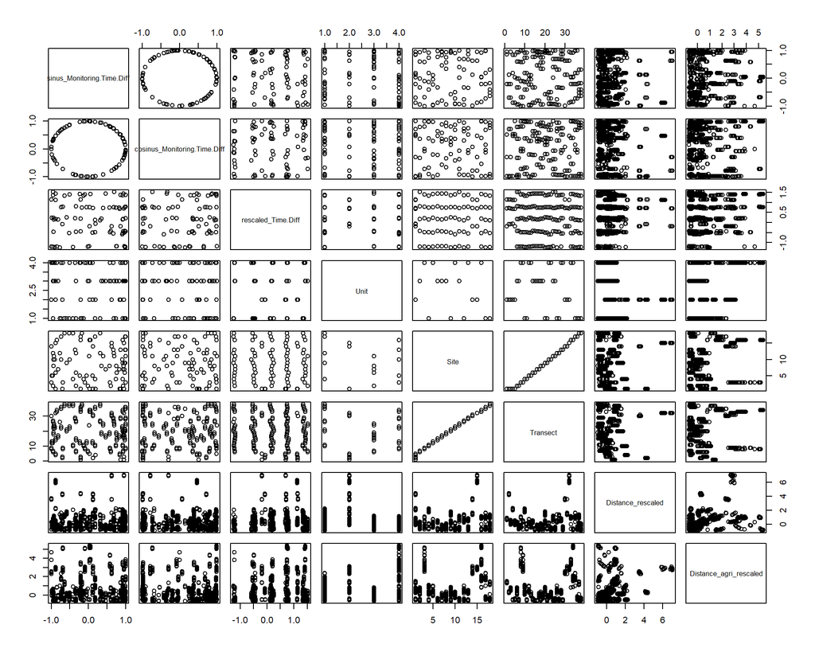

```r
pairs(P.anal[,lapply(X = .SD,FUN = as.numeric),.SDcols=c("sinus_Monitoring.Time.Diff", "cosinus_Monitoring.Time.Diff","rescaled_Time.Diff","Unit","Site","Transect", "Distance_rescaled", "Distance_agri_rescaled")])
```

```r
kable(cor(P.anal[,lapply(X = .SD,FUN = as.numeric),.SDcols=c("sinus_Monitoring.Time.Diff", "cosinus_Monitoring.Time.Diff","rescaled_Time.Diff","Unit","Site","Transect", "Distance_rescaled", "Distance_agri_rescaled")]))
```

|  | sinus_Monitoring.Time.Diff | cosinus_Monitoring.Time.Diff | rescaled_Time.Diff | Unit | Site | Transect | Distance_rescaled | Distance_agri_rescaled |
| --- | --- | --- | --- | --- | --- | --- | --- | --- |
| sinus_Monitoring.Time.Diff | 1.0000000 | 0.0105918 | -0.1332868 | -0.0524877 | 0.0433335 | 0.0453293 | 0.0074134 | -0.0140828 |
| cosinus_Monitoring.Time.Diff | 0.0105918 | 1.0000000 | 0.1390827 | -0.0383249 | 0.0235046 | 0.0300045 | -0.1326740 | 0.0574878 |
| rescaled_Time.Diff | -0.1332868 | 0.1390827 | 1.0000000 | 0.0443234 | -0.0319083 | -0.0318330 | 0.0449611 | 0.0482256 |
| Unit | -0.0524877 | -0.0383249 | 0.0443234 | 1.0000000 | -0.1776679 | -0.1635705 | -0.2487878 | 0.2447897 |
| Site | 0.0433335 | 0.0235046 | -0.0319083 | -0.1776679 | 1.0000000 | 0.9972061 | -0.0055375 | 0.1379800 |
| Transect | 0.0453293 | 0.0300045 | -0.0318330 | -0.1635705 | 0.9972061 | 1.0000000 | -0.0354120 | 0.1140970 |
| Distance_rescaled | 0.0074134 | -0.1326740 | 0.0449611 | -0.2487878 | -0.0055375 | -0.0354120 | 1.0000000 | 0.3127868 |
| Distance_agri_rescaled | -0.0140828 | 0.0574878 | 0.0482256 | 0.2447897 | 0.1379800 | 0.1140970 | 0.3127868 | 1.0000000 |

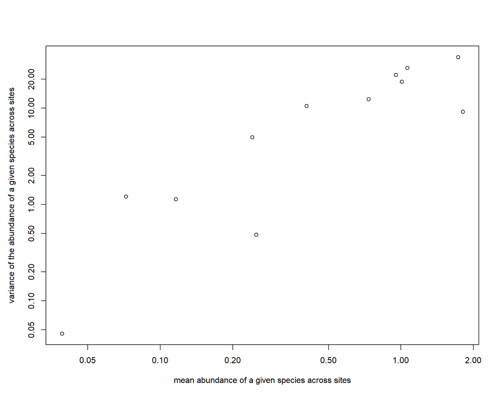

```r
meanvar.plot(spp, xlab = "mean abundance of a given species across sites", ylab = "variance of the abundance of a given species across sites")
```

```r
mdl_r.poiss.int <- glm(data = P.anal, formula = richness ~ rescaled_Time.Diff + cosinus_Monitoring.Time.Diff + sinus_Monitoring.Time.Diff + Unit + Site, family = poisson)
od <- mdl_r.poiss.int$deviance/mdl_r.poiss.int$df.residual
print("Estimating overdispersion parameter phi: (Res. Dev.)/(n-p) where n=number of observations; p=number of parameters in the model.")
```

```
## [1] "Estimating overdispersion parameter phi: (Res. Dev.)/(n-p) where n=number of observations; p=number of parameters in the model."
```

```r
print(paste0('od = ',od))
```

```
## [1] "od = 0.449491447135241"
```

Overdispersion parameter is <1 (underdispersion) and therefore will use Poisson

```r
m0 <- glm(data = P.anal, formula =  richness ~ rescaled_Time.Diff + cosinus_Monitoring.Time.Diff + sinus_Monitoring.Time.Diff, family = poisson)
AIC(m0)
```

```
## [1] 2989.733
```

```r
me0site <- glmer(data = P.anal, formula =   richness ~ rescaled_Time.Diff + cosinus_Monitoring.Time.Diff + sinus_Monitoring.Time.Diff +  (1|Site), family = poisson, verbose = 1)
```

[output not shown]

```r
AIC(me0site)
```

```
## [1] 2979.255
```

```r
me0unit <- glmer(data = P.anal, formula =   richness ~ rescaled_Time.Diff + cosinus_Monitoring.Time.Diff + sinus_Monitoring.Time.Diff +  (1|Unit), family = poisson, verbose = 1)
```

[output not shown]

```r
AIC(me0unit)
```

```
## [1] 2974.385
```

All GLMERs converge, will use model with unit (lowest AIC score)

```r
m1 <- glmer(data = P.anal, formula =   richness ~ rescaled_Time.Diff + cosinus_Monitoring.Time.Diff + sinus_Monitoring.Time.Diff +  (1|Unit), family = poisson)
drop1(m1)
```

```
## Single term deletions
##
## Model:
## richness ~ rescaled_Time.Diff + cosinus_Monitoring.Time.Diff +
##     sinus_Monitoring.Time.Diff + (1 | Unit)
##                              npar    AIC
## <none>                            2974.4
## rescaled_Time.Diff              1 3028.4
## cosinus_Monitoring.Time.Diff    1 2975.2
## sinus_Monitoring.Time.Diff      1 2972.5
```

Dropped sin time

```r
m2 <- glmer(data = P.anal, formula =   richness ~ rescaled_Time.Diff + cosinus_Monitoring.Time.Diff + (1|Unit), family = poisson)
drop1(m2)
```

```
## Single term deletions
##
## Model:
## richness ~ rescaled_Time.Diff + cosinus_Monitoring.Time.Diff +
##     (1 | Unit)
##                              npar    AIC
## <none>                            2972.5
## rescaled_Time.Diff              1 3027.9
## cosinus_Monitoring.Time.Diff    1 2973.2
```

Dropped cosin time

```r
m2 <- glmer(data = P.anal, formula =   richness ~ rescaled_Time.Diff + (1|Unit), family = poisson)
drop1(m2)
```

```
## Single term deletions
##
## Model:
## richness ~ rescaled_Time.Diff + (1 | Unit)
##                    npar    AIC
## <none>                  2973.2
## rescaled_Time.Diff    1 3034.9
```

Final model includes time difference

```r
summ(m2, exp = TRUE, digits=3)
```

| Observations | 998 |
| --- | --- |
| Dependent variable | richness |
| Type | Mixed effects generalized linear model |
| Family | poisson |
| Link | log |

| AIC | 2973.220 |
| --- | --- |
| BIC | 2987.937 |
| Pseudo-R² (fixed effects) | 0.069 |
| Pseudo-R² (total) | 0.123 |

| Fixed Effects | Fixed Effects exp(Est.) | Fixed Effects S.E. | Fixed Effects z val. | Fixed Effects p |
| --- | --- | --- | --- | --- |
| (Intercept) | 1.728 | 0.086 | 6.387 | 0.000 |
| rescaled_Time.Diff | 1.244 | 0.028 | 7.884 | 0.000 |

| Random Effects Group | Random Effects Parameter | Random Effects Std. Dev. |
| --- | --- | --- |
| Unit | (Intercept) | 0.160 |

| Grouping Variables Group | Grouping Variables # groups | Grouping Variables ICC |
| --- | --- | --- |
| Unit | 4 | 0.025 |

```
## Confidence intervals for merMod models is an experimental feature. The
## intervals reflect only the variance of the fixed effects, not the random
## effects.
```

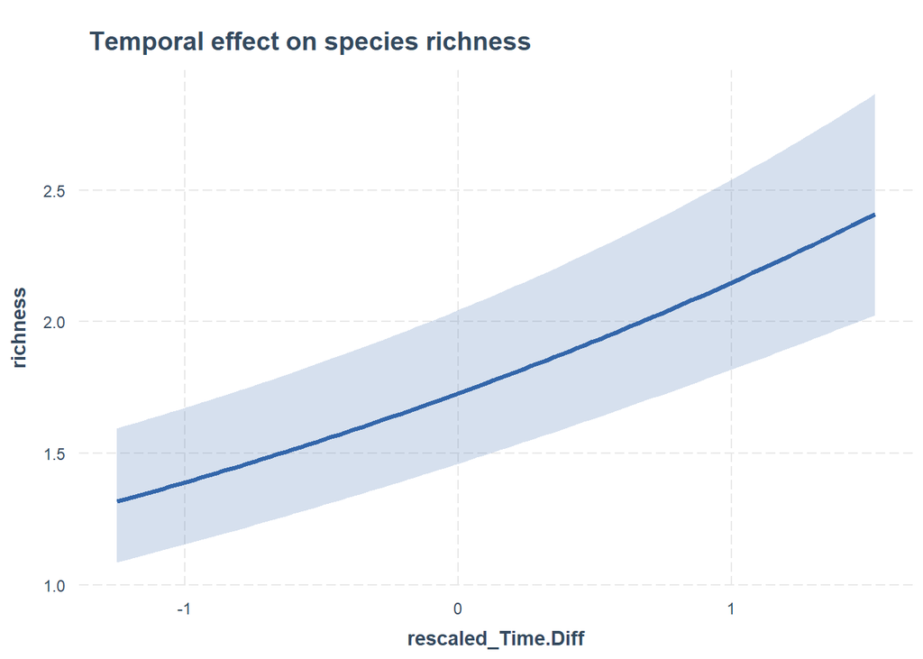

```r
effect_plot(model = m2, data=P.anal, pred = rescaled_Time.Diff, interval = T, plot.points = F, jitter = c(0.1,0), point.size = 3, cat.pred.point.size = 4, partial.residuals = F, colors = "Qual1", main.title = "Temporal effect on species richness")
```

There is a significant increase in mammal richness over time

#### Community analysis using package MVabund

Rare species filtering - at least 40 cameras

```r
abundance_and_cameras <- as.data.table(P.anal[,c(5,27:40)])
dim(abundance_and_cameras)
```

```
## [1] 998  15
```

```r
canisau <- abundance_and_cameras[,2] > 0
sum(canisau)
```

```
## [1] 336
```

```r
canislup <- abundance_and_cameras[,3] > 0
sum(canislup)
```

```
## [1] 55
```

```r
capra <- abundance_and_cameras[,4] > 0
sum(capra)
```

```
## [1] 41
```

```r
Gazellador <- abundance_and_cameras[,7] > 0
sum(Gazellador)
```

```
## [1] 195
```

```r
Hyaena <- abundance_and_cameras[,9] > 0
sum(Hyaena)
```

```
## [1] 167
```

```r
Hystrix <- abundance_and_cameras[,10] > 0
sum(Hystrix)
```

```
## [1] 190
```

```r
Lepus <- abundance_and_cameras[,11] > 0
sum(Lepus)
```

```
## [1] 263
```

```r
Vulpus <- abundance_and_cameras[,15] > 0
sum(Vulpus)
```

```
## [1] 565
```

998 cameras total,

Species for desert units analysis + a minimum of 40 deployments - Canis aureus, Canis lupus, Capra nubiana, Gazella dorcas, Hyaena hyaena, Hystrix indica, Lepus capensis and vulpus vulpus

```r
spp_no_rare <- P.anal[,27:40]
print(colSums(spp_no_rare))
```

```
##      Canis aureus       Canis lupus     Capra nubiana Dama mesopotamica
##              1727               241               405                 0
##    Equus hemionus    Gazella dorcas   Gazella gazella     Hyaena hyaena
##               116              1006               950               250
##    Hystrix indica    Lepus capensis       Meles meles     Oryx leucoryx
##               734              1062                39                72
##        Sus scrofa     Vulpes vulpes
##                 0              1804
```

```r
# filter out species with less than 20 individuals (rare species)
#spp_no_rare <- spp_no_rare[,.SD,.SDcols = colSums(spp_no_rare)>=196]
spp_no_rare <- mvabund(spp_no_rare[,c(-4:-5,-7,-11:-13)])
print(colSums(spp_no_rare))
```

```
##   Canis.aureus    Canis.lupus  Capra.nubiana Gazella.dorcas  Hyaena.hyaena
##           1727            241            405           1006            250
## Hystrix.indica Lepus.capensis  Vulpes.vulpes
##            734           1062           1804
```

Left with 8 species after rare species filtering

```r
max(abundance_and_cameras$'Canis aureus')
```

```
## [1] 105
```

```r
max(abundance_and_cameras$'Canis lupus')
```

```
## [1] 43
```

```r
max(abundance_and_cameras$'Capra nubiana')
```

```
## [1] 55
```

```r
max(abundance_and_cameras$'Gazella dorcas')
```

```
## [1] 76
```

```r
max(abundance_and_cameras$'Hyaena hyaena')
```

```
## [1] 9
```

```r
max(abundance_and_cameras$'Hystrix indica')
```

```
## [1] 65
```

```r
max(abundance_and_cameras$'Lepus capensis')
```

```
## [1] 114
```

```r
max(abundance_and_cameras$'Vulpes vulpes')
```

```
## [1] 35
```

```r
env_data <- P.anal[,..col_names]

mva_m0.po <- manyglm(formula = spp_no_rare ~ rescaled_Time.Diff + cosinus_Monitoring.Time.Diff + sinus_Monitoring.Time.Diff, family = "poisson", data = env_data)

mva_m0.nb <- manyglm(formula = spp_no_rare ~ rescaled_Time.Diff + cosinus_Monitoring.Time.Diff + sinus_Monitoring.Time.Diff, family = "negative.binomial", data = env_data)

aic_dt <- data.table(nb = mva_m0.nb$aic, po=mva_m0.po$aic)
colMeans(aic_dt)
```

```
##       nb       po
## 1835.886 3857.769
```

```r
print("POISSON")
```

```
## [1] "POISSON"
```

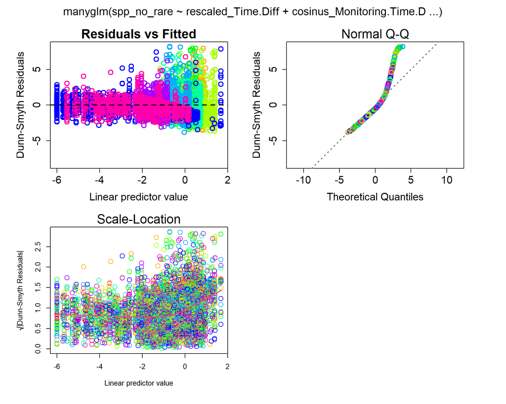

```r
plot(mva_m0.po, which=1:3)
```

```r
print("NEGATIVE BINOMIAL")
```

```
## [1] "NEGATIVE BINOMIAL"
```

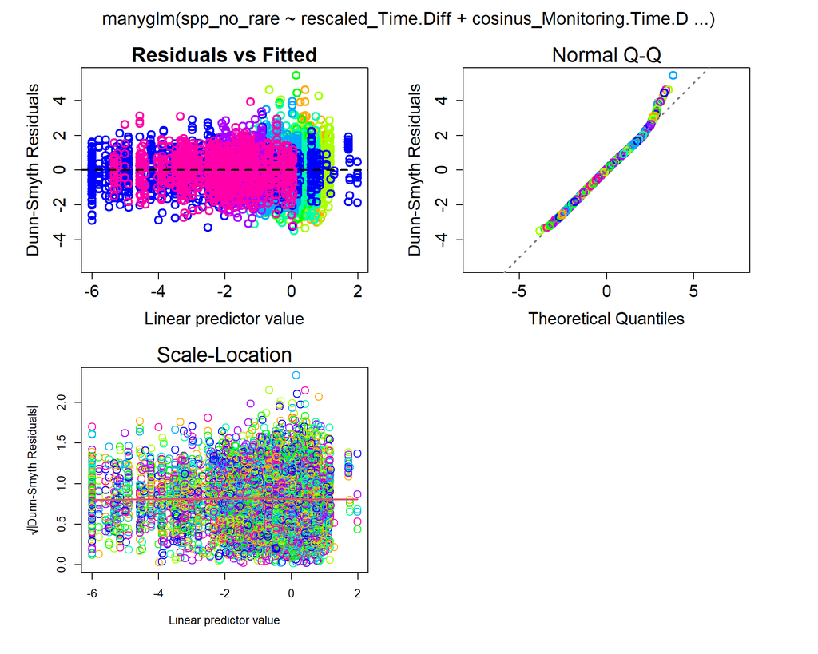

```r
plot(mva_m0.nb, which=1:3)
```

prefer negative binomial because standardized residuals are smaller.

```r
mva_m0 <- mva_m0.nb

mva_m2 <- manyglm(formula = spp_no_rare ~ rescaled_Time.Diff + cosinus_Monitoring.Time.Diff + sinus_Monitoring.Time.Diff + Site, data = env_data)
aic_dt$nb2 <- mva_m2$aic
colMeans(aic_dt)
```

```
##       nb       po      nb2
## 1835.886 3857.769 1667.213
```

```r
mva_m3 <- manyglm(formula = spp_no_rare ~ rescaled_Time.Diff + cosinus_Monitoring.Time.Diff + sinus_Monitoring.Time.Diff + Unit, data = env_data)
aic_dt$nb3 <- mva_m2$aic
colMeans(aic_dt)
```

```
##       nb       po      nb2      nb3
## 1835.886 3857.769 1667.213 1667.213
```

##Many GLM with site

```r
mva_m0.nb.site <- manyglm(formula = spp_no_rare ~ rescaled_Time.Diff + cosinus_Monitoring.Time.Diff + sinus_Monitoring.Time.Diff + Site, family = "negative.binomial", data = env_data)
drop1(mva_m0.nb.site)
```

```
## Single term deletions
##
## Model:
## spp_no_rare ~ rescaled_Time.Diff + cosinus_Monitoring.Time.Diff +
##     sinus_Monitoring.Time.Diff + Site
##                               Df   AIC
## <none>                           13338
## rescaled_Time.Diff             8 13452
## cosinus_Monitoring.Time.Diff   8 13342
## sinus_Monitoring.Time.Diff     8 13332
## Site                         136 14687
```

Dropped sin time

```r
mva_m1_site <- manyglm(formula = spp_no_rare ~ rescaled_Time.Diff + cosinus_Monitoring.Time.Diff + Site, family = "negative.binomial", data = env_data)
drop1(mva_m1_site)
```

```
## Single term deletions
##
## Model:
## spp_no_rare ~ rescaled_Time.Diff + cosinus_Monitoring.Time.Diff +
##     Site
##                               Df   AIC
## <none>                           13332
## rescaled_Time.Diff             8 13439
## cosinus_Monitoring.Time.Diff   8 13333
## Site                         136 14708
```

Dropped cosin

```r
mva_m1_site <- manyglm(formula = spp_no_rare ~ rescaled_Time.Diff + Site, family = "negative.binomial", data = env_data)
drop1(mva_m1_site)
```

```
## Single term deletions
##
## Model:
## spp_no_rare ~ rescaled_Time.Diff + Site
##                     Df   AIC
## <none>                 13333
## rescaled_Time.Diff   8 13459
## Site               136 14758
```

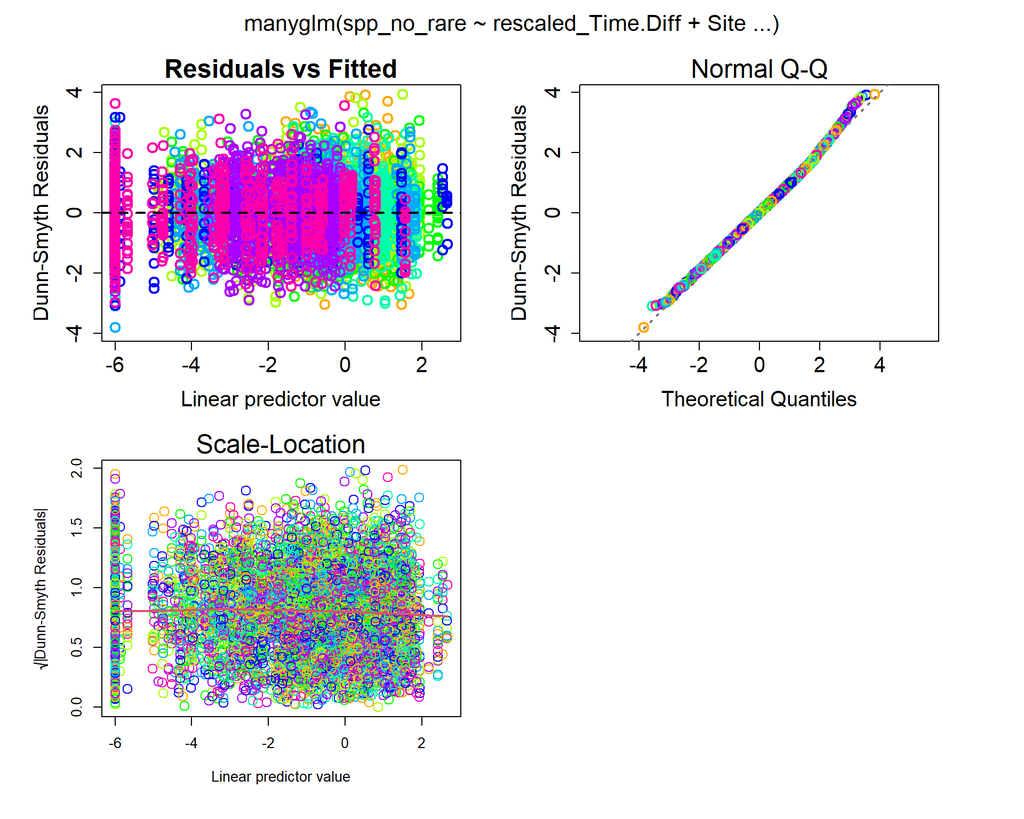

```r
plot(mva_m1_site, which=1:3)
```

```r
#summ_m2_site <- summary(mva_m1_site)
#anov_m2.uni_site <- anova(mva_m1_site, p.uni = "adjusted")
#saveRDS(summ_m2_site, "../output/national_desert_units/Summ_desert_all_sites.rds")
#saveRDS(anov_m2.uni_site, "../output/national_desert_units/Anova_desert_all_sites.rds")
summ_m2_site <- readRDS("../output/national_desert_units/Summ_desert_all_sites.rds")
anov_m2.uni_site <- readRDS("../output/national_desert_units/Anova_desert_all_sites.rds")
print(summ_m2_site)
```

```
##
## Test statistics:
##                    wald value Pr(>wald)
## (Intercept)             9.926     0.001 ***
## rescaled_Time.Diff     13.453     0.001 ***
## SiteBeit Yatir          7.829     0.001 ***
## SiteBislach             7.528     0.001 ***
## SiteEin Yahav          10.325     0.001 ***
## SiteEzuz                9.161     0.001 ***
## SiteHar Amasa           5.000     0.001 ***
## SiteLahav               7.801     0.001 ***
## SiteLehavim             5.330     0.001 ***
## SiteLotan               3.538     0.048 *
## SiteMerhav Am           9.388     0.001 ***
## SiteMirsham             5.730     0.002 **
## SiteParan               5.445     0.002 **
## SiteSde Boker           7.412     0.001 ***
## SiteSecher              2.319     0.181
## SiteShunra              0.970     0.897
## SiteYeruham             8.449     0.001 ***
## SiteYotvata             9.944     0.001 ***
## SiteZofar               9.651     0.001 ***
## ---
## Signif. codes:  0 '***' 0.001 '**' 0.01 '*' 0.05 '.' 0.1 ' ' 1
##
## Test statistic:  33.51, p-value: 0.001
## Arguments:
##  Test statistics calculated assuming response assumed to be uncorrelated
##  P-value calculated using 999 resampling iterations via pit.trap resampling (to account for correlation in testing).
```

```r
print(anov_m2.uni_site)
```

```
## Analysis of Deviance Table
##
## Model: spp_no_rare ~ rescaled_Time.Diff + Site
##
## Multivariate test:
##                    Res.Df Df.diff    Dev Pr(>Dev)
## (Intercept)           997
## rescaled_Time.Diff    996       1  122.6    0.001 ***
## Site                  979      17 1697.8    0.001 ***
## ---
## Signif. codes:  0 '***' 0.001 '**' 0.01 '*' 0.05 '.' 0.1 ' ' 1
##
## Univariate Tests:
##                    Canis.aureus          Canis.lupus          Capra.nubiana
##                             Dev Pr(>Dev)         Dev Pr(>Dev)           Dev
## (Intercept)
## rescaled_Time.Diff       42.306    0.001      14.183    0.027        23.119
## Site                    293.353    0.001     137.981    0.001       158.996
##                             Gazella.dorcas          Hyaena.hyaena
##                    Pr(>Dev)            Dev Pr(>Dev)           Dev Pr(>Dev)
## (Intercept)
## rescaled_Time.Diff    0.004         12.134    0.048         5.217    0.257
## Site                  0.001        237.425    0.001       114.048    0.001
##                    Hystrix.indica          Lepus.capensis
##                               Dev Pr(>Dev)            Dev Pr(>Dev)
## (Intercept)
## rescaled_Time.Diff           2.45    0.396          3.228    0.396
## Site                      325.343    0.001        217.354    0.001
##                    Vulpes.vulpes
##                              Dev Pr(>Dev)
## (Intercept)
## rescaled_Time.Diff        19.944    0.007
## Site                     213.292    0.001
## Arguments:
##  Test statistics calculated assuming uncorrelated response (for faster computation)
## P-value calculated using 999 iterations via PIT-trap resampling.
```

**Multivariate test shows that Site and time difference significantly affect species composition**

```r
coefp_site <- merge(data.table(t(coef(mva_m1_site)/log(2)),keep.rownames=TRUE), data.table(t(anov_m2.uni_site$uni.p), keep.rownames = TRUE), by = "rn") # coefficients are exponentiated because the link function used for poisson is log -> above 1 is positive and below 1 is negative
# add total species abundance
coefp_site <- merge(coefp_site,as.data.table(colSums(spp_no_rare),keep.rownames = TRUE), by.x = "rn", by.y = "V1")

#colnames(coefp_site) <- c("SciName","Intercept.coef","Time_diff.coef","Cosin_time.coef","Inland_sands.coef","MD_tranzition_zone.coef","Negev_highlands.coef", "Intercept.p","Time_diff.p","Cosin_time.p","Site.p","species_abundance")

# write.csv(coefp_site, "../output/national_desert_units/coefficients_National_data_desert_units_by_site.csv")

print(coefp_site)
```

```
##                rn (Intercept).x rescaled_Time.Diff.x SiteBeit Yatir SiteBislach
## 1:   Canis.aureus    -2.4709258            0.6933988      3.6924699   2.3980898
## 2:    Canis.lupus   -22.5480701            1.8563692      0.5491228  15.2544403
## 3:  Capra.nubiana   -20.0293999           -2.1350786     -0.8811226  16.3953536
## 4: Gazella.dorcas    -1.2647248            1.0558410    -20.4282093   0.1854839
## 5:  Hyaena.hyaena    -4.5558819            0.3153945      0.4011489   3.9243687
## 6: Hystrix.indica   -21.5408493            0.2634545     15.4515931  20.8392614
## 7: Lepus.capensis    -1.9265561            0.5826313      1.0902950   1.2236354
## 8:  Vulpes.vulpes     0.1693509            0.4461730      1.0278453  -1.5039889
##    SiteEin Yahav   SiteEzuz SiteHar Amasa   SiteLahav SiteLehavim   SiteLotan
## 1:    -3.7020911  3.9792417     1.6316482   3.8340003   1.0962245 -0.66557224
## 2:    20.2821807  0.4049676     0.3117166   0.6238806   0.4829688 21.12450115
## 3:    -1.0092866 -0.6613161    -0.5724381  -0.8914401  -0.7705492 21.05395258
## 4:     2.5462046  1.0986720   -20.5913044 -20.3932970 -20.4815965  1.33203505
## 5:     2.3868732  0.9820649     1.3122877   0.8278188  -0.2150946  2.20398739
```

[output cut: 30 more lines]

```r
sites2keep <- P.anal[,sum(`Canis aureus`),keyby=Site][V1>0,Site]
Canis.aureus.subset.Sites <- P.anal[Site %in% sites2keep]
dim(Canis.aureus.subset.Sites)
```

```
## [1] 980  43
```

```r
#Canis.aureus <- spp_no_rare[,"Canis.aureus"]
glm.Canis.aureus <- glm.nb(formula = `Canis aureus` ~ rescaled_Time.Diff + Site, data = Canis.aureus.subset.Sites)
coef(glm.Canis.aureus)
```

```
##        (Intercept) rescaled_Time.Diff     SiteBeit Yatir        SiteBislach
##         -1.7127159          0.4806283          2.5594265          1.6622299
##      SiteEin Yahav           SiteEzuz      SiteHar Amasa          SiteLahav
##         -2.5660938          2.7582009          1.1309725          2.6575266
##        SiteLehavim          SiteLotan      SiteMerhav Am        SiteMirsham
##          0.7598456         -0.4613393          2.9880362          1.8641803
##          SiteParan      SiteSde Boker         SiteShunra        SiteYeruham
##         -2.4014366          2.3115997         -0.7930927          2.4906029
##        SiteYotvata          SiteZofar
##          2.5506453         -1.4450905
```

```r
coef(mva_m1_site)
```

```
##                    Canis.aureus  Canis.lupus Capra.nubiana Gazella.dorcas
## (Intercept)          -1.7127152 -15.62913119  -13.88332208    -0.87664046
## rescaled_Time.Diff    0.4806274   1.28673705   -1.47992372     0.73185318
## SiteBeit Yatir        2.5594251   0.38062292   -0.61074762   -14.15975569
## SiteBislach           1.6622292  10.57357231   11.36439315     0.12856762
## SiteEin Yahav        -2.5660940  14.05853637   -0.69958415     1.76489454
## SiteEzuz              2.7582002   0.28070212   -0.45838937     0.76154142
## SiteHar Amasa         1.1309724   0.21606549   -0.39678387   -14.27280461
## SiteLahav             2.6575265   0.43244106   -0.61789919   -14.13555630
## SiteLehavim           0.7598449   0.33476849   -0.53410399   -14.19676088
## SiteLotan            -0.4613395  14.64238841   14.59348787     0.92329634
## SiteMerhav Am         2.9880366  11.35971382   -0.34090340    -0.78411265
## SiteMirsham           1.8641795   0.36827754   -0.52043364   -14.16891372
## SiteParan            -2.4014368  14.07206620   -0.51970416     1.62222099
## SiteSde Boker         2.3115996   0.20068890   10.05945362     0.41320536
## SiteSecher          -13.3623868   0.11864172   -0.13359031     0.18395293
## SiteShunra           -0.7930926   0.05110796   -0.05824018     0.00711528
## SiteYeruham           2.4906032  10.63256226   -0.47863280   -14.21659385
## SiteYotvata           2.5506457  15.43003191   14.70674678     1.35237405
## SiteZofar            -1.4450909  12.90369606   -0.64274876     1.47313782
##                    Hyaena.hyaena Hystrix.indica Lepus.capensis Vulpes.vulpes
## (Intercept)           -3.1578967  -14.930978951    -1.33538695    0.11738509
## rescaled_Time.Diff     0.2186148    0.182612710     0.40384923    0.30926356
## SiteBeit Yatir         0.2780552   10.710228190     0.75573489    0.71244804
## SiteBislach            2.7201651   14.444675291     0.84815942   -1.04248564
## SiteEin Yahav          1.6544544    0.073440822     3.21190039   -0.69201697
## SiteEzuz               0.6807155   14.679126432     1.38357027   -1.26079928
## SiteHar Amasa          0.9096085   12.377017705     0.70758998    0.76886252
## SiteLahav              0.5738003   14.298270231    -2.70411322    0.64980041
## SiteLehavim           -0.1490922   13.987953771     1.74831054    0.63079317
## SiteLotan              1.5276876    0.065572143     0.23026828    0.17083012
## SiteMerhav Am          1.9479680   15.279286439    -0.49354172    0.70406618
## SiteMirsham            0.6168716   14.627009549    -1.54283639    0.40560590
## SiteParan              1.5728930    0.058456982     0.98289857   -0.03400597
## SiteSde Boker          1.7830541   14.975477006    -0.09515331    0.57707341
## SiteSecher           -11.7756898    0.016837532     0.45872381    0.71859023
## SiteShunra           -11.7871637    0.007253193    -0.27035417   -0.02367469
## SiteYeruham            2.6367473   16.495168676     0.50652071    0.29627790
## SiteYotvata            2.0994773   11.360095174    -0.02508446    1.12515271
## SiteZofar              2.4259188   14.062166637     2.06888051   -2.07757137
```

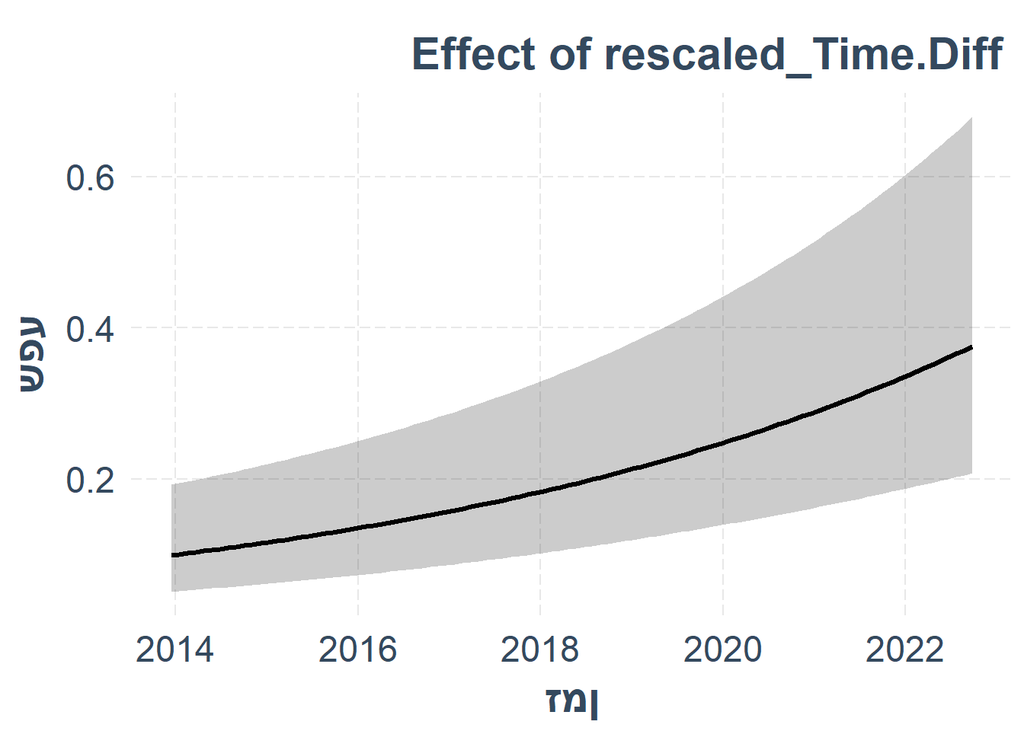

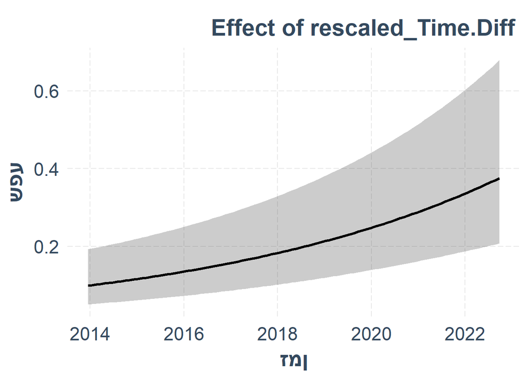

```r
# effect_plot(model = glm.Canis.aureus, data=Canis.aureus.subset.Sites, pred = rescaled_Time.Diff, interval = T, plot.points = F, jitter = c(0.1,0), partial.residuals = F, colors = "Qual1") +  scale_x_continuous(breaks=c(-1.233466888,-0.601840099,0.028922631,0.66054942,1.291312151), labels=c("June 2014", "June 2016", "June 2018", "June 2020", "June 2022"), name = "Time")

plot_model_effect(P.anal = Canis.aureus.subset.Sites, m = glm.Canis.aureus, eff2plot = "rescaled_Time.Diff", plot_points=FALSE, plot_residuals=FALSE, export_plot=TRUE, ylabel = NULL, fontname = "Almoni ML v5 AAA", fontsize=22, pdf_width=160, outpath = "../output/national_desert_units/")
```

```r
sites2keep <- P.anal[,sum(`Canis lupus`),keyby=Site][V1>0,Site]
Canis.lupus.subset.Sites <- P.anal[Site %in% sites2keep]
dim(Canis.lupus.subset.Sites)
```

```
## [1] 484  43
```

```r
#Canis.lupus <- spp_no_rare[,"Canis.lupus"]
glm.Canis.lupus <- glm.nb(formula = `Canis lupus` ~ rescaled_Time.Diff + Site, data = Canis.lupus.subset.Sites)
coef(glm.Canis.lupus)
```

```
##        (Intercept) rescaled_Time.Diff      SiteEin Yahav          SiteLotan
##        -5.05557417         1.28675061         3.48497970         4.06879687
##      SiteMerhav Am          SiteParan        SiteYeruham        SiteYotvata
##         0.78614627         3.49850229         0.05899063         4.85647799
##          SiteZofar
##         2.33013137
```

```r
coef(mva_m1_site)
```

```
##                    Canis.aureus  Canis.lupus Capra.nubiana Gazella.dorcas
## (Intercept)          -1.7127152 -15.62913119  -13.88332208    -0.87664046
## rescaled_Time.Diff    0.4806274   1.28673705   -1.47992372     0.73185318
## SiteBeit Yatir        2.5594251   0.38062292   -0.61074762   -14.15975569
## SiteBislach           1.6622292  10.57357231   11.36439315     0.12856762
## SiteEin Yahav        -2.5660940  14.05853637   -0.69958415     1.76489454
## SiteEzuz              2.7582002   0.28070212   -0.45838937     0.76154142
## SiteHar Amasa         1.1309724   0.21606549   -0.39678387   -14.27280461
## SiteLahav             2.6575265   0.43244106   -0.61789919   -14.13555630
## SiteLehavim           0.7598449   0.33476849   -0.53410399   -14.19676088
## SiteLotan            -0.4613395  14.64238841   14.59348787     0.92329634
## SiteMerhav Am         2.9880366  11.35971382   -0.34090340    -0.78411265
## SiteMirsham           1.8641795   0.36827754   -0.52043364   -14.16891372
## SiteParan            -2.4014368  14.07206620   -0.51970416     1.62222099
## SiteSde Boker         2.3115996   0.20068890   10.05945362     0.41320536
## SiteSecher          -13.3623868   0.11864172   -0.13359031     0.18395293
## SiteShunra           -0.7930926   0.05110796   -0.05824018     0.00711528
## SiteYeruham           2.4906032  10.63256226   -0.47863280   -14.21659385
## SiteYotvata           2.5506457  15.43003191   14.70674678     1.35237405
## SiteZofar            -1.4450909  12.90369606   -0.64274876     1.47313782
##                    Hyaena.hyaena Hystrix.indica Lepus.capensis Vulpes.vulpes
## (Intercept)           -3.1578967  -14.930978951    -1.33538695    0.11738509
## rescaled_Time.Diff     0.2186148    0.182612710     0.40384923    0.30926356
## SiteBeit Yatir         0.2780552   10.710228190     0.75573489    0.71244804
## SiteBislach            2.7201651   14.444675291     0.84815942   -1.04248564
## SiteEin Yahav          1.6544544    0.073440822     3.21190039   -0.69201697
## SiteEzuz               0.6807155   14.679126432     1.38357027   -1.26079928
## SiteHar Amasa          0.9096085   12.377017705     0.70758998    0.76886252
## SiteLahav              0.5738003   14.298270231    -2.70411322    0.64980041
## SiteLehavim           -0.1490922   13.987953771     1.74831054    0.63079317
## SiteLotan              1.5276876    0.065572143     0.23026828    0.17083012
## SiteMerhav Am          1.9479680   15.279286439    -0.49354172    0.70406618
## SiteMirsham            0.6168716   14.627009549    -1.54283639    0.40560590
## SiteParan              1.5728930    0.058456982     0.98289857   -0.03400597
## SiteSde Boker          1.7830541   14.975477006    -0.09515331    0.57707341
## SiteSecher           -11.7756898    0.016837532     0.45872381    0.71859023
## SiteShunra           -11.7871637    0.007253193    -0.27035417   -0.02367469
## SiteYeruham            2.6367473   16.495168676     0.50652071    0.29627790
## SiteYotvata            2.0994773   11.360095174    -0.02508446    1.12515271
## SiteZofar              2.4259188   14.062166637     2.06888051   -2.07757137
```

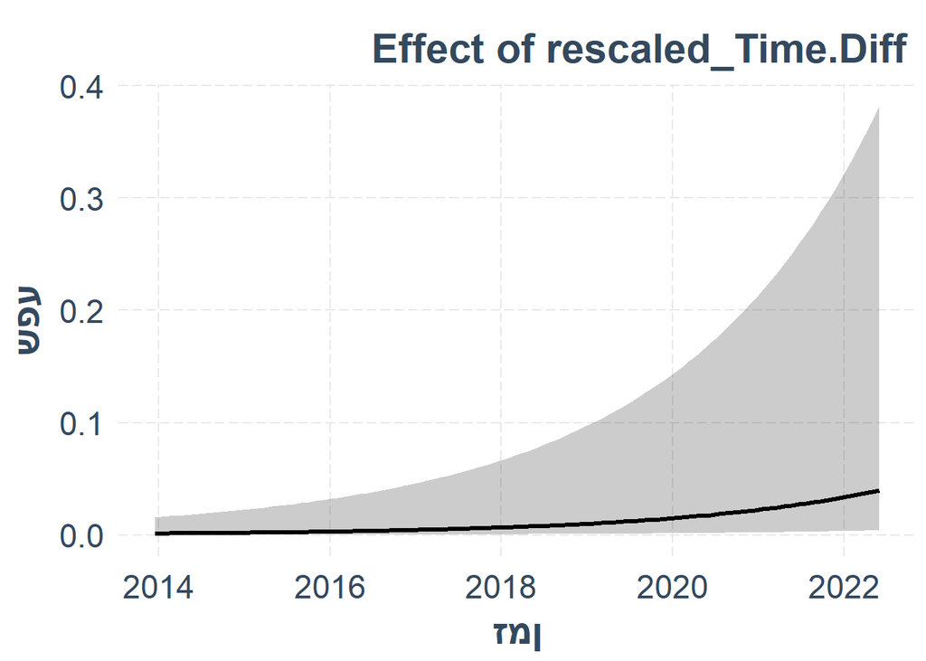

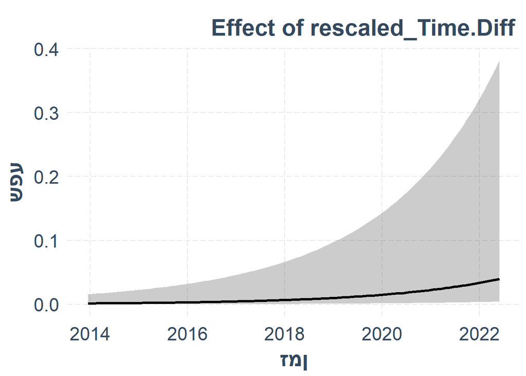

```r
# effect_plot(model = glm.Canis.lupus, data=Canis.lupus.subset.Sites, pred = rescaled_Time.Diff, interval = T, plot.points = F, jitter = c(0.1,0), partial.residuals = F, colors = "Qual1") +  scale_x_continuous(breaks=c(-1.233466888,-0.601840099,0.028922631,0.66054942,1.291312151), labels=c("June 2014", "June 2016", "June 2018", "June 2020", "June 2022"), name = "Time")

plot_model_effect(P.anal = Canis.lupus.subset.Sites, m = glm.Canis.lupus, eff2plot = "rescaled_Time.Diff", plot_points=FALSE, plot_residuals=FALSE, export_plot=TRUE, ylabel = NULL, fontname = "Almoni ML v5 AAA", fontsize=22, pdf_width=160, outpath = "../output/national_desert_units/")
```

```r
# sites2keep <- P.anal[,sum(`Capra nubiana`),keyby=Site][V1>0,Site]
# Capra.subset.Sites <- P.anal[Site %in% sites2keep]
# dim(Capra.subset.Sites)
# #Capra.nubiana <- spp_no_rare[,"Capra.nubiana"]
# glm.Capra.nubiana <- glm.nb(formula = `Capra nubiana` ~ rescaled_Time.Diff + Site, data = Capra.subset.Sites)
# coef(glm.Capra.nubiana)
# coef(mva_m1_site)

# effect_plot(model = glm.Capra.nubiana, data=Capra.subset.Sites, pred = rescaled_Time.Diff, interval = T, plot.points = F, jitter = c(0.1,0), partial.residuals = F, colors = "Qual1") +  scale_x_continuous(breaks=c(-1.233466888,-0.601840099,0.028922631,0.66054942,1.291312151), labels=c("June 2014", "June 2016", "June 2018", "June 2020", "June 2022"), name = "Time")
#
# plot_model_effect(P.anal = Capra.subset.Sites, m = glm.Capra.nubiana, eff2plot = "rescaled_Time.Diff", plot_points=FALSE, plot_residuals=FALSE, export_plot=TRUE, ylabel = NULL, fontname = "Almoni ML v5 AAA", fontsize=22, pdf_width=160, outpath = "../output/national_desert_units/")

sites2keep <- P.anal[,sum(`Gazella dorcas`),keyby=Site][V1>0,Site]
Gazella.dorcas.subset.Sites <- P.anal[Site %in% sites2keep]
dim(Gazella.dorcas.subset.Sites)
```

```
## [1] 648  43
```

```r
#Gazella.dorcas <- spp_no_rare[,"Gazella.dorcas"]
glm.Gazella.dorcas <- glm.nb(formula = `Gazella dorcas` ~ rescaled_Time.Diff + Site, data = Gazella.dorcas.subset.Sites)
coef(glm.Gazella.dorcas)
```

```
##        (Intercept) rescaled_Time.Diff        SiteBislach      SiteEin Yahav
##       -0.876637099        0.731846558        0.128572465        1.764886891
##           SiteEzuz          SiteLotan      SiteMerhav Am          SiteParan
##        0.761540614        0.923295505       -0.784108372        1.622216868
##      SiteSde Boker         SiteSecher         SiteShunra        SiteYotvata
##        0.413195375        0.183958794        0.007112793        1.352371834
##          SiteZofar
##        1.473144414
```

```r
coef(mva_m1_site)
```

```
##                    Canis.aureus  Canis.lupus Capra.nubiana Gazella.dorcas
## (Intercept)          -1.7127152 -15.62913119  -13.88332208    -0.87664046
## rescaled_Time.Diff    0.4806274   1.28673705   -1.47992372     0.73185318
## SiteBeit Yatir        2.5594251   0.38062292   -0.61074762   -14.15975569
## SiteBislach           1.6622292  10.57357231   11.36439315     0.12856762
## SiteEin Yahav        -2.5660940  14.05853637   -0.69958415     1.76489454
## SiteEzuz              2.7582002   0.28070212   -0.45838937     0.76154142
## SiteHar Amasa         1.1309724   0.21606549   -0.39678387   -14.27280461
## SiteLahav             2.6575265   0.43244106   -0.61789919   -14.13555630
## SiteLehavim           0.7598449   0.33476849   -0.53410399   -14.19676088
## SiteLotan            -0.4613395  14.64238841   14.59348787     0.92329634
## SiteMerhav Am         2.9880366  11.35971382   -0.34090340    -0.78411265
## SiteMirsham           1.8641795   0.36827754   -0.52043364   -14.16891372
## SiteParan            -2.4014368  14.07206620   -0.51970416     1.62222099
## SiteSde Boker         2.3115996   0.20068890   10.05945362     0.41320536
## SiteSecher          -13.3623868   0.11864172   -0.13359031     0.18395293
## SiteShunra           -0.7930926   0.05110796   -0.05824018     0.00711528
## SiteYeruham           2.4906032  10.63256226   -0.47863280   -14.21659385
## SiteYotvata           2.5506457  15.43003191   14.70674678     1.35237405
## SiteZofar            -1.4450909  12.90369606   -0.64274876     1.47313782
##                    Hyaena.hyaena Hystrix.indica Lepus.capensis Vulpes.vulpes
## (Intercept)           -3.1578967  -14.930978951    -1.33538695    0.11738509
## rescaled_Time.Diff     0.2186148    0.182612710     0.40384923    0.30926356
## SiteBeit Yatir         0.2780552   10.710228190     0.75573489    0.71244804
## SiteBislach            2.7201651   14.444675291     0.84815942   -1.04248564
## SiteEin Yahav          1.6544544    0.073440822     3.21190039   -0.69201697
## SiteEzuz               0.6807155   14.679126432     1.38357027   -1.26079928
## SiteHar Amasa          0.9096085   12.377017705     0.70758998    0.76886252
## SiteLahav              0.5738003   14.298270231    -2.70411322    0.64980041
## SiteLehavim           -0.1490922   13.987953771     1.74831054    0.63079317
## SiteLotan              1.5276876    0.065572143     0.23026828    0.17083012
## SiteMerhav Am          1.9479680   15.279286439    -0.49354172    0.70406618
## SiteMirsham            0.6168716   14.627009549    -1.54283639    0.40560590
## SiteParan              1.5728930    0.058456982     0.98289857   -0.03400597
## SiteSde Boker          1.7830541   14.975477006    -0.09515331    0.57707341
## SiteSecher           -11.7756898    0.016837532     0.45872381    0.71859023
## SiteShunra           -11.7871637    0.007253193    -0.27035417   -0.02367469
## SiteYeruham            2.6367473   16.495168676     0.50652071    0.29627790
## SiteYotvata            2.0994773   11.360095174    -0.02508446    1.12515271
## SiteZofar              2.4259188   14.062166637     2.06888051   -2.07757137
```

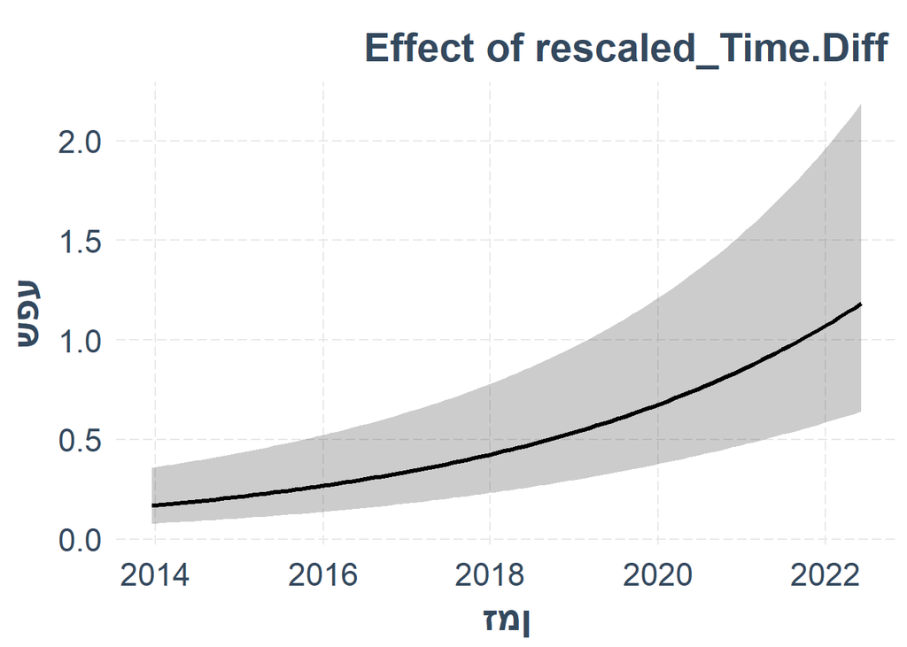

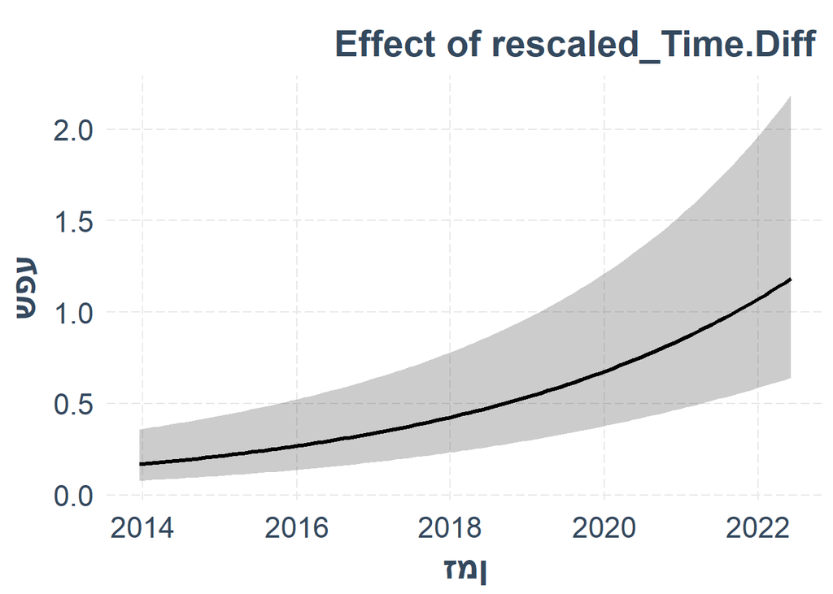

```r
# effect_plot(model = glm.Gazella.dorcas, data=Gazella.dorcas.subset.Sites, pred = rescaled_Time.Diff, interval = T, plot.points = F, jitter = c(0.1,0), partial.residuals = F, colors = "Qual1") +  scale_x_continuous(breaks=c(-1.233466888,-0.601840099,0.028922631,0.66054942,1.291312151), labels=c("June 2014", "June 2016", "June 2018", "June 2020", "June 2022"), name = "Time")

plot_model_effect(P.anal = Gazella.dorcas.subset.Sites, m = glm.Gazella.dorcas, eff2plot = "rescaled_Time.Diff", plot_points=FALSE, plot_residuals=FALSE, export_plot=TRUE, ylabel = NULL, fontname = "Almoni ML v5 AAA", fontsize=22, pdf_width=160, outpath = "../output/national_desert_units/")
```

```r
sites2keep <- P.anal[,sum(`Vulpes vulpes`),keyby=Site][V1>0,Site]
Vulpes.subset.Sites <- P.anal[Site %in% sites2keep]
dim(Vulpes.subset.Sites)
```

```
## [1] 998  43
```

```r
#Vulpes.vulpes <- spp_no_rare[,"Vulpes.vulpes"]
glm.Vulpes.vulpes <- glm.nb(formula = `Vulpes vulpes` ~ rescaled_Time.Diff + Site, data = Vulpes.subset.Sites)
coef(glm.Vulpes.vulpes)
```

```
##        (Intercept) rescaled_Time.Diff     SiteBeit Yatir        SiteBislach
##         0.11738447         0.30926454         0.71244786        -1.04248582
##      SiteEin Yahav           SiteEzuz      SiteHar Amasa          SiteLahav
##        -0.69201669        -1.26079979         0.76886230         0.64980029
##        SiteLehavim          SiteLotan      SiteMerhav Am        SiteMirsham
##         0.63079329         0.17083015         0.70406653         0.40560599
##          SiteParan      SiteSde Boker         SiteSecher         SiteShunra
##        -0.03400416         0.57707452         0.71859052        -0.02367486
##        SiteYeruham        SiteYotvata          SiteZofar
##         0.29627786         1.12515392        -2.07757137
```

```r
coef(mva_m1_site)
```

```
##                    Canis.aureus  Canis.lupus Capra.nubiana Gazella.dorcas
## (Intercept)          -1.7127152 -15.62913119  -13.88332208    -0.87664046
## rescaled_Time.Diff    0.4806274   1.28673705   -1.47992372     0.73185318
## SiteBeit Yatir        2.5594251   0.38062292   -0.61074762   -14.15975569
## SiteBislach           1.6622292  10.57357231   11.36439315     0.12856762
## SiteEin Yahav        -2.5660940  14.05853637   -0.69958415     1.76489454
## SiteEzuz              2.7582002   0.28070212   -0.45838937     0.76154142
## SiteHar Amasa         1.1309724   0.21606549   -0.39678387   -14.27280461
## SiteLahav             2.6575265   0.43244106   -0.61789919   -14.13555630
## SiteLehavim           0.7598449   0.33476849   -0.53410399   -14.19676088
## SiteLotan            -0.4613395  14.64238841   14.59348787     0.92329634
## SiteMerhav Am         2.9880366  11.35971382   -0.34090340    -0.78411265
## SiteMirsham           1.8641795   0.36827754   -0.52043364   -14.16891372
## SiteParan            -2.4014368  14.07206620   -0.51970416     1.62222099
## SiteSde Boker         2.3115996   0.20068890   10.05945362     0.41320536
## SiteSecher          -13.3623868   0.11864172   -0.13359031     0.18395293
## SiteShunra           -0.7930926   0.05110796   -0.05824018     0.00711528
## SiteYeruham           2.4906032  10.63256226   -0.47863280   -14.21659385
## SiteYotvata           2.5506457  15.43003191   14.70674678     1.35237405
## SiteZofar            -1.4450909  12.90369606   -0.64274876     1.47313782
##                    Hyaena.hyaena Hystrix.indica Lepus.capensis Vulpes.vulpes
## (Intercept)           -3.1578967  -14.930978951    -1.33538695    0.11738509
## rescaled_Time.Diff     0.2186148    0.182612710     0.40384923    0.30926356
## SiteBeit Yatir         0.2780552   10.710228190     0.75573489    0.71244804
## SiteBislach            2.7201651   14.444675291     0.84815942   -1.04248564
## SiteEin Yahav          1.6544544    0.073440822     3.21190039   -0.69201697
## SiteEzuz               0.6807155   14.679126432     1.38357027   -1.26079928
## SiteHar Amasa          0.9096085   12.377017705     0.70758998    0.76886252
## SiteLahav              0.5738003   14.298270231    -2.70411322    0.64980041
## SiteLehavim           -0.1490922   13.987953771     1.74831054    0.63079317
## SiteLotan              1.5276876    0.065572143     0.23026828    0.17083012
## SiteMerhav Am          1.9479680   15.279286439    -0.49354172    0.70406618
## SiteMirsham            0.6168716   14.627009549    -1.54283639    0.40560590
## SiteParan              1.5728930    0.058456982     0.98289857   -0.03400597
## SiteSde Boker          1.7830541   14.975477006    -0.09515331    0.57707341
## SiteSecher           -11.7756898    0.016837532     0.45872381    0.71859023
## SiteShunra           -11.7871637    0.007253193    -0.27035417   -0.02367469
## SiteYeruham            2.6367473   16.495168676     0.50652071    0.29627790
## SiteYotvata            2.0994773   11.360095174    -0.02508446    1.12515271
## SiteZofar              2.4259188   14.062166637     2.06888051   -2.07757137
```

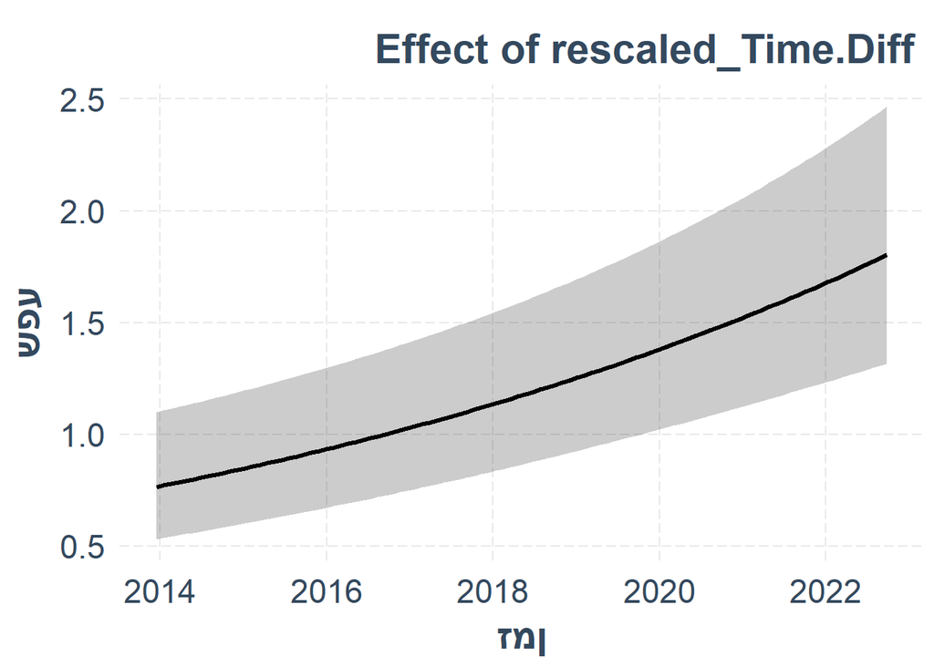

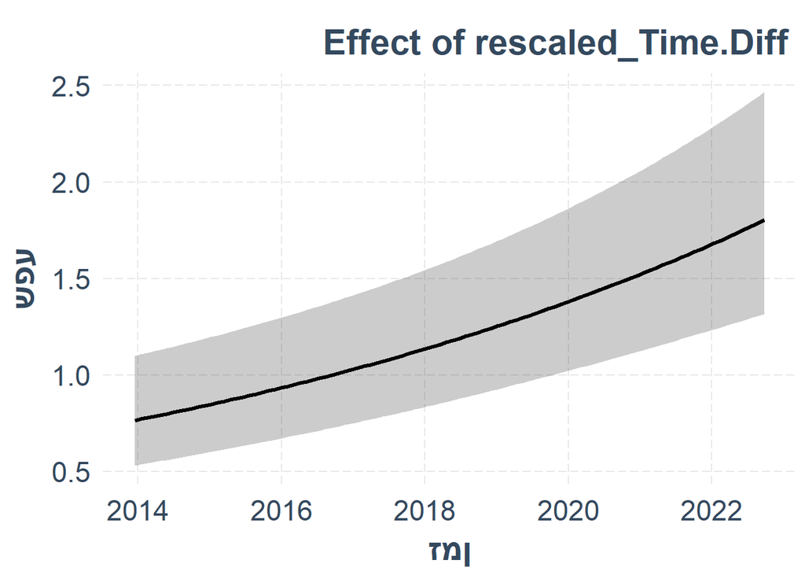

```r
# effect_plot(model = glm.Vulpes.vulpes, data=Vulpes.subset.Sites, pred = rescaled_Time.Diff, interval = T, plot.points = F, jitter = c(0.1,0), partial.residuals = F, colors = "Qual1") +  scale_x_continuous(breaks=c(-1.233466888,-0.601840099,0.028922631,0.66054942,1.291312151), labels=c("June 2014", "June 2016", "June 2018", "June 2020", "June 2022"), name = "Time")

plot_model_effect(P.anal = Vulpes.subset.Sites, m = glm.Vulpes.vulpes, eff2plot = "rescaled_Time.Diff", plot_points=FALSE, plot_residuals=FALSE, export_plot=TRUE, ylabel = NULL, fontname = "Almoni ML v5 AAA", fontsize=22, pdf_width=160, outpath = "../output/national_desert_units/")
```

## Desert units - only far transects

```r
only.far <- P.anal[grepl("Far",Settlements) | grepl("Far", Agriculture),][order(Unit,Site)]
dim(only.far)
```

```
## [1] 538  43
```

```r
print(nrow(only.far[Unit == "Arid Desert"]))
```

```
## [1] 165
```

```r
print(nrow(only.far[Unit == "Inland Sands"]))
```

```
## [1] 85
```

```r
print(nrow(only.far[Unit == "Mediterranean Desert Transition Zone"]))
```

```
## [1] 139
```

```r
print(nrow(only.far[Unit == "Negev Highlands"]))
```

```
## [1] 149
```

# Species filtering - national species + minimum 40 cameras

```r
abundance_and_cameras_far <- as.data.table(only.far[,c(5,27:40)])
dim(abundance_and_cameras_far)
```

```
## [1] 538  15
```

```r
canisau <- abundance_and_cameras_far[,2] > 0
sum(canisau)
```

```
## [1] 130
```

```r
canislup <- abundance_and_cameras_far[,3] > 0
sum(canislup)
```

```
## [1] 29
```

```r
capra <- abundance_and_cameras_far[,4] > 0
sum(capra)
```

```
## [1] 40
```

```r
Gazellador <- abundance_and_cameras_far[,7] > 0
sum(Gazellador)
```

```
## [1] 153
```

```r
Hyaena <- abundance_and_cameras_far[,9] > 0
sum(Hyaena)
```

```
## [1] 91
```

```r
Hystrix <- abundance_and_cameras_far[,10] > 0
sum(Hystrix)
```

```
## [1] 82
```

```r
Lepus <- abundance_and_cameras_far[,11] > 0
sum(Lepus)
```

```
## [1] 149
```

```r
Vulpus <- abundance_and_cameras_far[,15] > 0
sum(Vulpus)
```

```
## [1] 288
```

538 cameras total,

Species for national analyses + a minimum of 40 cameras - Canis aureus, Capra nubiana, Gazella dorcas, Hyaena hyaena, Hystrix indica, Lepus capensis and vulpus vulpus

```r
spp_no_rare_far <- only.far[,27:40]
print(colSums(spp_no_rare_far))
```

```
##      Canis aureus       Canis lupus     Capra nubiana Dama mesopotamica
##               494               193               404                 0
##    Equus hemionus    Gazella dorcas   Gazella gazella     Hyaena hyaena
##                76               767               368               132
##    Hystrix indica    Lepus capensis       Meles meles     Oryx leucoryx
##               198               606                20                72
##        Sus scrofa     Vulpes vulpes
##                 0               801
```

```r
# filter out species
spp_no_rare_far <- mvabund(spp_no_rare_far[,c(-2,-4:-5,-7,-11:-13)])
print(colSums(spp_no_rare_far))
```

```
##   Canis.aureus  Capra.nubiana Gazella.dorcas  Hyaena.hyaena Hystrix.indica
##            494            404            767            132            198
## Lepus.capensis  Vulpes.vulpes
##            606            801
```

Left with 7 species

```r
env_data_far <- only.far[,..col_names]

mva_m0.po.far <- manyglm(formula = spp_no_rare_far ~ rescaled_Time.Diff + cosinus_Monitoring.Time.Diff + sinus_Monitoring.Time.Diff + Site + Unit, family = "poisson", data = env_data_far)

mva_m0.nb.far <- manyglm(formula = spp_no_rare_far ~ rescaled_Time.Diff + cosinus_Monitoring.Time.Diff + sinus_Monitoring.Time.Diff + Site + Unit, family = "negative.binomial", data = env_data_far)

aic_dt <- data.table(nb = mva_m0.nb.far$aic, po=mva_m0.po.far$aic)
colMeans(aic_dt)
```

```
##        nb        po
##  944.2218 1451.9355
```

```r
print("POISSON")
```

```
## [1] "POISSON"
```

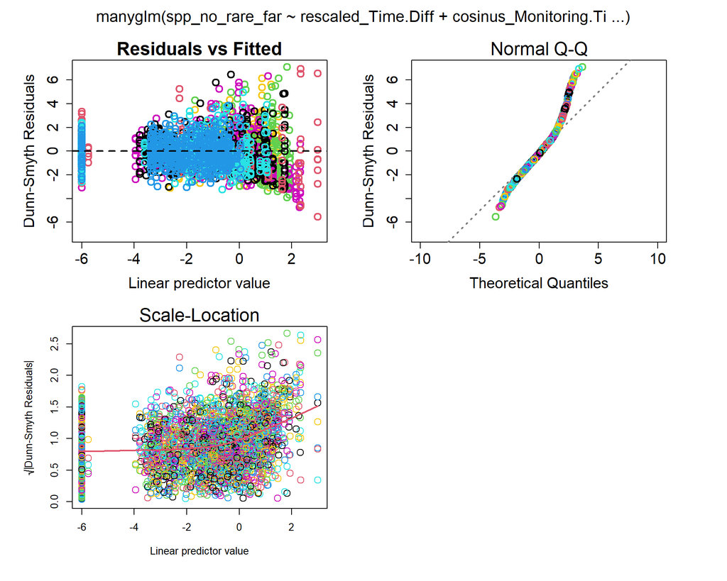

```r
plot(mva_m0.po.far, which=1:3)
```

```r
print("NEGATIVE BINOMIAL")
```

```
## [1] "NEGATIVE BINOMIAL"
```

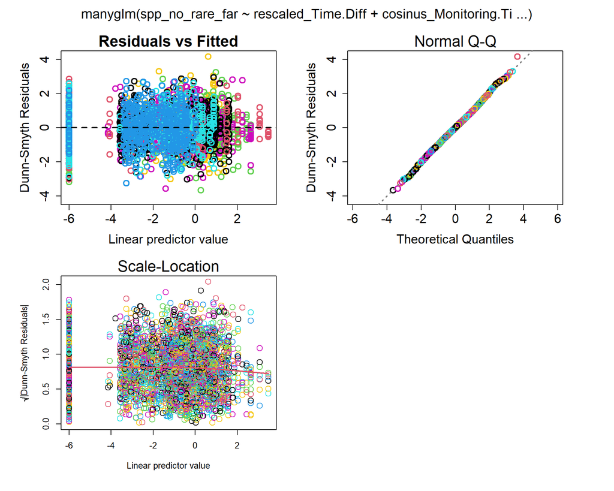

```r
plot(mva_m0.nb.far, which=1:3)
```

prefer negative binomial because standardized residuals are smaller.

```r
mva_m1_far <- manyglm(formula = spp_no_rare_far ~ Distance_rescaled * rescaled_Time.Diff + cosinus_Monitoring.Time.Diff + sinus_Monitoring.Time.Diff, data = env_data_far)
aic_dt$nb1 <- mva_m1_far$aic
colMeans(aic_dt)
```

```
##        nb        po       nb1
##  944.2218 1451.9355 1044.3981
```

```r
mva_m2_far <- manyglm(formula = spp_no_rare_far ~ Distance_rescaled * rescaled_Time.Diff + cosinus_Monitoring.Time.Diff + sinus_Monitoring.Time.Diff + Site, data = env_data_far)
aic_dt$nb2 <- mva_m2_far$aic
colMeans(aic_dt)
```

```
##        nb        po       nb1       nb2
##  944.2218 1451.9355 1044.3981  940.7450
```

```r
mva_m3_far <- manyglm(formula = spp_no_rare_far ~ Distance_rescaled * rescaled_Time.Diff + cosinus_Monitoring.Time.Diff + sinus_Monitoring.Time.Diff + Unit, data = env_data_far)
aic_dt$nb3 <- mva_m3_far$aic
colMeans(aic_dt)
```

```
##        nb        po       nb1       nb2       nb3
##  944.2218 1451.9355 1044.3981  940.7450  978.4440
```

Site and unit improve the model

# Many glm only far - Site

```r
mva_m0_far_site <- manyglm(formula = spp_no_rare_far ~ rescaled_Time.Diff + cosinus_Monitoring.Time.Diff + sinus_Monitoring.Time.Diff + Site, family = "negative.binomial", data = env_data_far)
drop1(mva_m0_far_site)
```

```
## Single term deletions
##
## Model:
## spp_no_rare_far ~ rescaled_Time.Diff + cosinus_Monitoring.Time.Diff +
##     sinus_Monitoring.Time.Diff + Site
##                               Df    AIC
## <none>                           6567.6
## rescaled_Time.Diff             7 6645.9
## cosinus_Monitoring.Time.Diff   7 6570.9
## sinus_Monitoring.Time.Diff     7 6559.4
## Site                         119 7360.8
```

dropped sin time

```r
mva_m2_far_site <- manyglm(formula = spp_no_rare_far ~ rescaled_Time.Diff + cosinus_Monitoring.Time.Diff + Site, family = "negative.binomial", data = env_data_far)
drop1(mva_m2_far_site)
```

```
## Single term deletions
##
## Model:
## spp_no_rare_far ~ rescaled_Time.Diff + cosinus_Monitoring.Time.Diff +
##     Site
##                               Df    AIC
## <none>                           6559.4
## rescaled_Time.Diff             7 6634.0
## cosinus_Monitoring.Time.Diff   7 6561.6
## Site                         119 7386.5
```

dropped cosin time

```r
mva_m2_far_site <- manyglm(formula = spp_no_rare_far ~ rescaled_Time.Diff + Site, family = "negative.binomial", data = env_data_far)
drop1(mva_m2_far_site)
```

```
## Single term deletions
##
## Model:
## spp_no_rare_far ~ rescaled_Time.Diff + Site
##                     Df    AIC
## <none>                 6561.6
## rescaled_Time.Diff   7 6635.2
## Site               119 7426.0
```

```r
# mva_m2 <- manyglm(formula = spp_no_rare_far ~ rescaled_Time.Diff + Site, family = "negative.binomial", data = env_data)
# drop1(mva_m2)
```

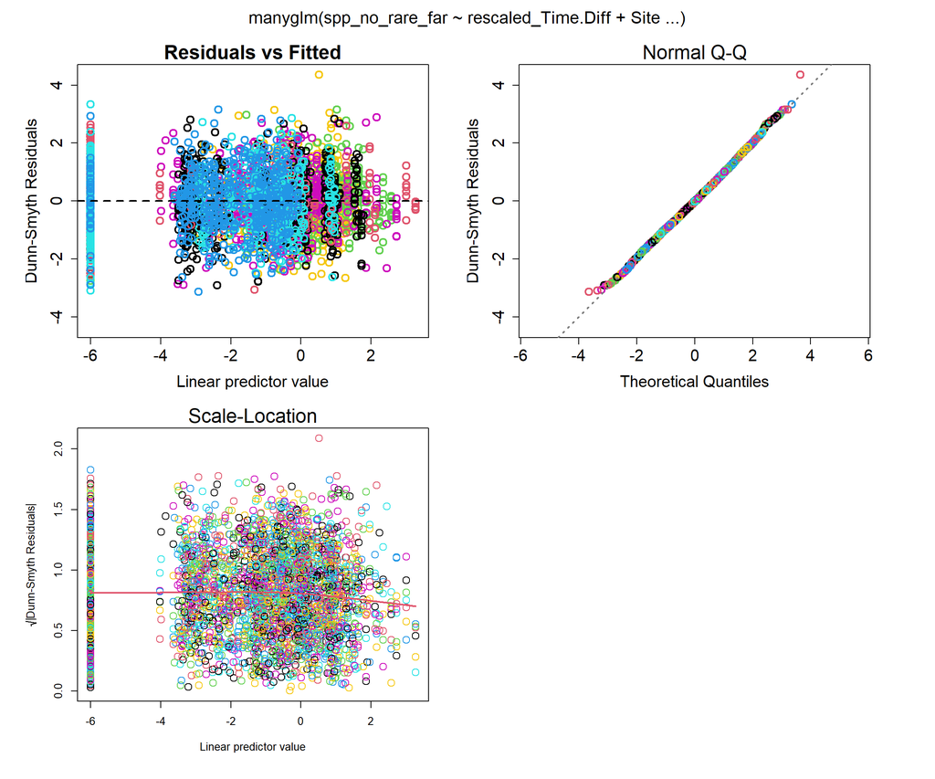

```r
plot(mva_m2_far_site, which=1:3)
```

```r
#summ_m2_far_site <- summary(mva_m2_far_site)
#anov_m2.uni_far_site <- anova(mva_m2_far_site, p.uni = "adjusted")
#saveRDS(summ_m2_far_site, "../output/national_desert_units/Summ_desert_far_sites.rds")
#saveRDS(anov_m2.uni_far_site, "../output/national_desert_units/Anova_desert_far_sites.rds")
summ_m2_far_site <- readRDS("../output/national_desert_units/Summ_desert_far_sites.rds")
anov_m2.uni_far_site <- readRDS("../output/national_desert_units/Anova_desert_far_sites.rds")
print(summ_m2_far_site)
```

```
##
## Test statistics:
##                    wald value Pr(>wald)
## (Intercept)             7.987     0.001 ***
## rescaled_Time.Diff     10.943     0.001 ***
## SiteBeit Yatir          6.498     0.001 ***
## SiteBislach             5.772     0.001 ***
## SiteEin Yahav           9.865     0.001 ***
## SiteEzuz                6.971     0.001 ***
## SiteHar Amasa           5.162     0.001 ***
## SiteLahav               5.481     0.001 ***
## SiteLehavim             4.917     0.001 ***
## SiteLotan               4.699     0.002 **
## SiteMerhav Am           7.772     0.001 ***
## SiteMirsham             4.883     0.001 ***
## SiteParan               5.819     0.001 ***
## SiteSde Boker           5.603     0.001 ***
## SiteSecher              3.118     0.021 *
## SiteShunra              1.185     0.818
## SiteYeruham             6.895     0.001 ***
## SiteYotvata             5.722     0.001 ***
## SiteZofar               7.347     0.001 ***
## ---
## Signif. codes:  0 '***' 0.001 '**' 0.01 '*' 0.05 '.' 0.1 ' ' 1
##
## Test statistic:  26.33, p-value: 0.001
## Arguments:
##  Test statistics calculated assuming response assumed to be uncorrelated
##  P-value calculated using 999 resampling iterations via pit.trap resampling (to account for correlation in testing).
```

```r
print(anov_m2.uni_far_site)
```

```
## Analysis of Deviance Table
##
## Model: spp_no_rare_far ~ rescaled_Time.Diff + Site
##
## Multivariate test:
##                    Res.Df Df.diff    Dev Pr(>Dev)
## (Intercept)           537
## rescaled_Time.Diff    536       1   53.2    0.001 ***
## Site                  519      17 1102.4    0.001 ***
## ---
## Signif. codes:  0 '***' 0.001 '**' 0.01 '*' 0.05 '.' 0.1 ' ' 1
##
## Univariate Tests:
##                    Canis.aureus          Capra.nubiana          Gazella.dorcas
##                             Dev Pr(>Dev)           Dev Pr(>Dev)            Dev
## (Intercept)
## rescaled_Time.Diff        0.636    0.826        21.795    0.007          3.502
## Site                    181.189    0.001       173.197    0.001        215.037
##                             Hyaena.hyaena          Hystrix.indica
##                    Pr(>Dev)           Dev Pr(>Dev)            Dev Pr(>Dev)
## (Intercept)
## rescaled_Time.Diff    0.517         2.188    0.668           0.99    0.824
## Site                  0.001         75.84    0.001         141.78    0.001
##                    Lepus.capensis          Vulpes.vulpes
##                               Dev Pr(>Dev)           Dev Pr(>Dev)
## (Intercept)
## rescaled_Time.Diff          0.544    0.826        23.587    0.004
## Site                      155.075    0.001       160.287    0.001
## Arguments:
##  Test statistics calculated assuming uncorrelated response (for faster computation)
## P-value calculated using 999 iterations via PIT-trap resampling.
```

```r
coefp_far_site <- merge(data.table(t(coef(mva_m2_far_site)/log(2)),keep.rownames=TRUE), data.table(t(anov_m2.uni_far_site$uni.p), keep.rownames = TRUE), by = "rn") # coefficients are exponentiated because the link function used for poisson is log -> above 1 is positive and below 1 is negative
# add total species abundance
coefp_far_site <- merge(coefp_far_site,as.data.table(colSums(spp_no_rare_far),keep.rownames = TRUE), by.x = "rn", by.y = "V1")

#colnames(coefp_far_site) <- c("SciName","Intercept.coef","Time_diff.coef","Cosin_time.coef","Sin_time.coef","Inland_sands.coef","MD_tranzition_zone.coef","Negev_highlands.coef", "Intercept.p","Time_diff.p","Cosin_time.p","Sin_time.p","Unit.p","species_abundance")

# write.csv(coefp_far_site, "../output/national_desert_units/coefficients_Desert_units_far_sites.csv")

print(coefp_far_site)
```

```
##                rn (Intercept).x rescaled_Time.Diff.x SiteBeit Yatir SiteBislach
## 1:   Canis.aureus    -4.5651896           -0.1414121     5.77211946   4.7119423
## 2:  Capra.nubiana   -20.0589208           -2.0633172    -0.97271742  17.1605584
## 3: Gazella.dorcas    -0.9468420            1.1138507   -20.69967921  -0.6169268
## 4:  Hyaena.hyaena    -4.8548535            0.3115956     1.61715069   3.3749279
## 5: Hystrix.indica   -21.3059492           -0.1069836    -0.04216455  19.6190976
## 6: Lepus.capensis    -2.5203966            0.6863090     2.26253134   1.7221179
## 7:  Vulpes.vulpes    -0.1778905            0.5641611     1.06378654  -1.0780570
##    SiteEin Yahav   SiteEzuz SiteHar Amasa   SiteLahav SiteLehavim    SiteLotan
## 1:  -16.78903640  5.9923075     3.9635942   4.7848065   3.0172083   0.30476809
## 2:   -1.14319546 -0.8440305    -0.5929162  -0.6049513  -0.9284243  21.82873718
## 3:    3.17349555  0.7811764   -20.9099892 -20.8496734 -20.7140155   1.77769024
## 4:    2.62111805  0.8518871     0.8622956   1.2280660   1.0176892   2.93362377
## 5:   -0.05315527 20.3741448    18.4849923  19.1458355  20.9507921  -0.05534857
## 6:    5.53537925  2.7689907     1.9834027  -2.2371341   1.4180705 -18.93704436
```

[output cut: 25 more lines]

```r
# sites2keep <- only.far[,sum(`Capra nubiana`),keyby=Site][V1>0,Site]
# Capra.subset.Sites <- only.far[Site %in% sites2keep]
# dim(Capra.subset.Sites)
# #Capra.nubiana <- spp_no_rare_far[,"Capra.nubiana"]
# glm.Capra.nubiana <- glm.nb(formula =  `Capra nubiana` ~ rescaled_Time.Diff + cosinus_Monitoring.Time.Diff + sinus_Monitoring.Time.Diff + Unit, data = Capra.subset.Sites)
# coef(glm.Capra.nubiana)

# effect_plot(model = glm.Capra.nubiana, data=Capra.subset.Sites, pred = rescaled_Time.Diff, interval = T, plot.points = F, jitter = c(0.1,0), partial.residuals = F, colors = "Qual1") + scale_x_continuous(breaks=c(-1.233466888,-0.601840099,0.028922631,0.66054942,1.291312151), labels=c("June 2014", "June 2016", "June 2018", "June 2020", "June 2022"), name = "Time")
#
# plot_model_effect(P.anal = Capra.subset.Sites, m = glm.Capra.nubiana, eff2plot = "rescaled_Time.Diff", plot_points=FALSE, plot_residuals=FALSE, export_plot=TRUE, ylabel = NULL, fontname = "Almoni ML v5 AAA", fontsize=22, pdf_width=160, outpath = "../output/national_desert_units/")

sites2keep <- only.far[,sum(`Vulpes vulpes`),keyby=Site][V1>0,Site]
Vulpes.subset.Sites <- only.far[Site %in% sites2keep]
dim(Vulpes.subset.Sites)
```

```
## [1] 538  43
```

```r
#Vulpes.vulpes <- spp_no_rare_far[,"Vulpes.vulpes"]
glm.Vulpes.vulpes <- glm.nb(formula = `Vulpes vulpes` ~ rescaled_Time.Diff + cosinus_Monitoring.Time.Diff + sinus_Monitoring.Time.Diff + Unit, data = Vulpes.subset.Sites)
coef(glm.Vulpes.vulpes)
```

```
##                              (Intercept)
##                               -0.5705596
##                       rescaled_Time.Diff
##                                0.3942029
##             cosinus_Monitoring.Time.Diff
##                                0.1012647
##               sinus_Monitoring.Time.Diff
##                                0.1708173
##                         UnitInland Sands
##                                0.7885682
## UnitMediterranean Desert Transition Zone
##                                1.3373559
##                      UnitNegev Highlands
##                                0.5957073
```

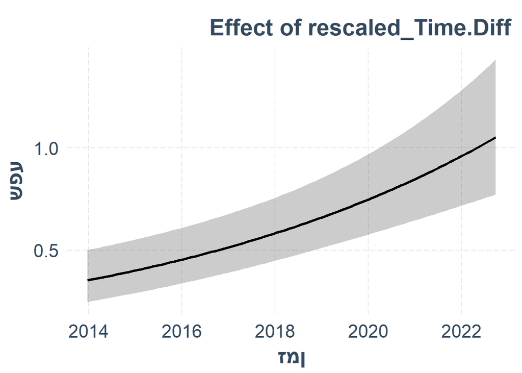

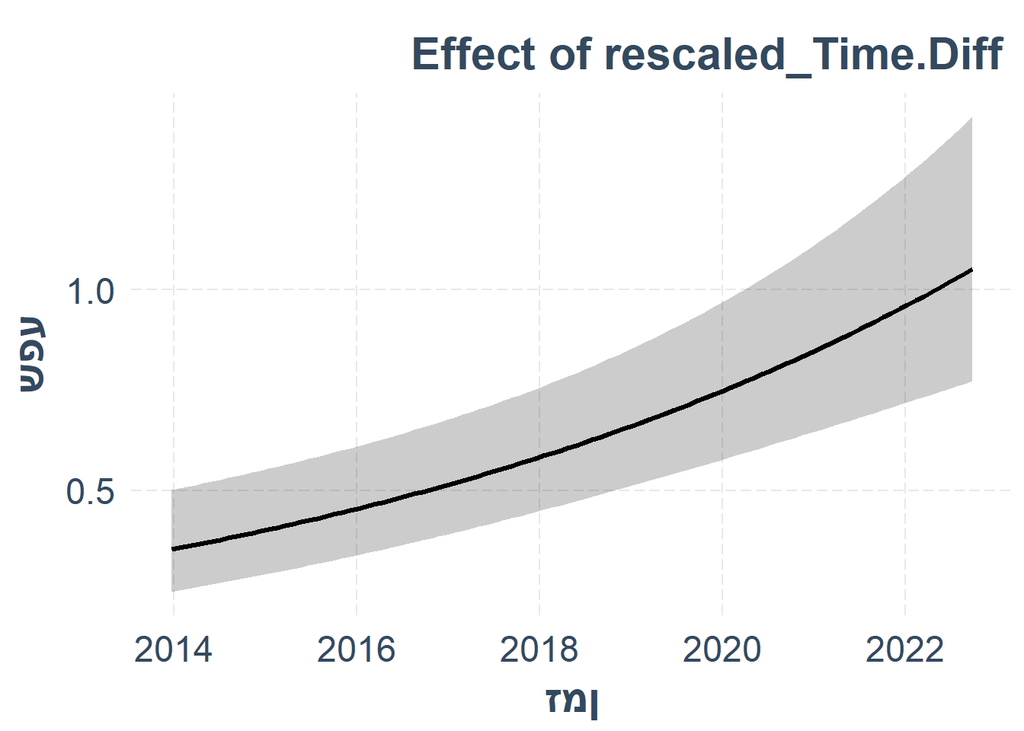

```r
# effect_plot(model = glm.Vulpes.vulpes, data=Vulpes.subset.Sites, pred = rescaled_Time.Diff, interval = T, plot.points = F, jitter = c(0.1,0), partial.residuals = F, colors = "Qual1") + scale_x_continuous(breaks=c(-1.233466888,-0.601840099,0.028922631,0.66054942,1.291312151), labels=c("June 2014", "June 2016", "June 2018", "June 2020", "June 2022"), name = "Time")

plot_model_effect(P.anal = Vulpes.subset.Sites, m = glm.Vulpes.vulpes, eff2plot = "rescaled_Time.Diff", plot_points=FALSE, plot_residuals=FALSE, export_plot=TRUE, ylabel = NULL, fontname = "Almoni ML v5 AAA", fontsize=22, pdf_width=160, outpath = "../output/national_desert_units/fig_only_far/")
```